# Projekt 3

# **Analiza wariancji**

Yurii Petrenko, grupa 3

### **Wstęp**

Analiza wariancji ANOVA jest jedną z najbardziej popularnych i najczęściej stosowanych analiz statystycznych. Dokładniej - analizą wariancji określa się grupę analiz, służących do badania wpływu czynników (zmiennych niezależnych) na zmienną zależną.

Możemy podzielić analizę wariancji na trzy grupy analiz:

1. jednoczynnikowa analiza wariancji
- (wpływ jednego czynnika międzygrupowego na zmienną zależną)
2. wieloczynnikowa analiza wariancji
- (wpływ kliku czynników międzygrupowych na zmienną zależną)
3. analiza wariancji dla czynników wewnątrzgrupowych
- (wpływ czynnika wewnątrzgrupowego na zmienną zależną, tzw. “powtarzane pomiary”)

Ideą analizy wariancji jest sprawdzenie czy pewne zmienne niezależne (czynniki) mają wpływ na poziom zmiennej zależnej (zmiennej testowanej, mierzonej). W zależności od rodzaju czynników stosujemy różne rodzaje analizy wariancji.

**Analiza wariancji** to stosunek wariancji, którą obliczyliśmy pomiędzy badanymi grupami a średnią wariancją, którą zaobserwowaliśmy wewnątrz grup (nie mylić z czynnikami między i wewnątrzgrupowymi). Analiza ta jest metodą statystyczną pozwalającą na podział zaobserwowanej zmienności (wariancji) wyników na oddzielne części. Analizowana jest wariancji przypadająca na każdy z analizowanych czynników jak również wariancji błędu.

Jednym z podstawowych zagadnień w analizie wariancji jest oszacowanie tzw. Średnich Kwadratów (MS). Stosunek średnich kwadratów obliczanych dla poszczególnych czynników w odniesieniu do średniego kwadratu błędu pozwala oszacować nam wpływ każdego z czynników oddzielnie na poziom zmiennej zależnej.

W porównaniu do innych, prostszych metod analizy danych np: testy t-Studenta, testy nieparametryczne **analiza wariancji ANOVA** pozwala nam na porównywanie nie tylko zmiennych mających więcej niż 2 poziomy (grupy), ale pozwala również analizować równoczesny wpływ kilku czynników naraz (MANOVA) oraz efekty interakcyjne pomiędzy tymi czynnikami.

**Celem projektu** jest analiza danych dla zestawu poker,przeanalizowanie jakie efekty mają wpływ na rezultat gry

### **Przegląd wybranych narzędzi:**

Dla prowadzenia analizy wzykorzystane będzie środowisko $R-Studio$ i język programowania $R$

Instalujemy pakiety:

```r
library(psych)
library(nortest)
library(car)
require(DescTools)
library(sjstats)
library("ggpubr")
library(PMCMRplus)
library(outliers)
```

### **Opis zbioru danych:**

Zbiur składa się z 3 zmiennych i 300 obserwacji

1. **result** -> wynnik gry
2. **hand** -> siła ręki(siła pierwszych dwóch kart)
3. **skill** -> poziom umiejętności

Budujemy wykresy pudełkowe oraz sprawdzamy statystyki opisowe wewnątrz grup

Na wykresach wyrażnie widzimy duża ilość outlierów dla grup expert, bad, good, neutral

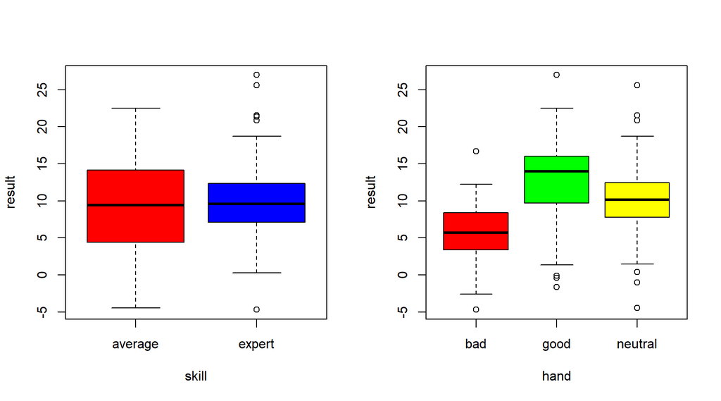

```
##     item  group1 vars   n  mean   sd median trimmed  mad   min   max range
## X11    1     bad    1 100  5.78 3.62   5.70    5.77 3.88 -4.68 16.68 21.36
## X12    2    good    1 100 12.98 4.76  13.96   13.25 3.95 -1.61 26.99 28.60
## X13    3 neutral    1 100 10.24 4.50  10.16   10.24 3.47 -4.47 25.63 30.10
##      skew kurtosis   se
## X11  0.02     0.09 0.36
## X12 -0.55     1.09 0.48
## X13  0.06     1.74 0.45
```

Zbiur podzielony na grupy względem siły ręki

```
##     item  group1 vars   n  mean   sd median trimmed  mad   min   max range
## X11    1 average    1 150  9.26 5.76   9.41    9.31 7.38 -4.47 22.48 26.95
## X12    2  expert    1 150 10.07 4.64   9.59    9.93 3.91 -4.68 26.99 31.67
##      skew kurtosis   se
## X11 -0.05    -0.92 0.47
## X12  0.45     1.60 0.38
```

Względem umiejętnośći dzielimy graczy na:

- averege
- expert

Ciekawe jest to że zgodnie ze statystykami powyzej, przeciętne graczy a eksperci zarabiają mniej więcej tyle samo, średnia i mediana jest na dość podobnym poziomie. Różnią się oni tylko tym że eksperci mają mniejszą wariancje uzyskanych wynników

```
##          hand
## skill     bad good neutral
##   average  50   50      50
##   expert   50   50      50
```

Jeżeli podzielimy zbiur na grupy względem umiejętności i siły ręki, w wyniku otrzymujemy po 50 odserwacji w każdej grupie , co jest bardzo dużo

```
##          hand
## skill        bad    good neutral
##   average 4.4450 13.7148  9.6250
##   expert  7.1092 12.2552 10.8494
```

Poruwnując między sobą średnie można zauważyć że najwięcej się wygrywa kiedy jesteś przeciętnym graczem z dobrymi kartami

Najmniej wygrywa średnio-zawansowany z złymi kartami

Eksperci natomiast nie mają takiego dużego rozrzutu między wynikami

```
##          hand
## skill          bad     good  neutral
##   average 2.949420 5.316217 4.440943
##   expert  3.757982 4.058093 4.520944
```

### **Badanie empiryczne:**

#### **Wartości odstające**

Przed sprawdzaniem normalności, żeby uzyskać wiarygodne wyniki należy wyrzucić ze zbioru outliery

Dla poradzenia sobie z takim problemem skorzystamy z testu $Grubbsa$

Algorytm wygląda następująco:

1. Sprawdzam kurtozy dla każdej z grup

```
##    average     expert
## -0.9179947  1.6007058
```

```
##        bad       good    neutral
## 0.09308517 1.09231991 1.74321220
```

Jeżeli kurtoza jest większa od 1 to należy zastanowić się nad wystąpieniem w danym zbiorze danych odstających

Dla grupy expert kurtoza wynosi 1.60070 co jest istotnie większe od 1, należy usunąć jakiegoś experta

2. Sprawdzamy testem Grubbsa outliery i usuwamy ich

p-value:

- około 1 słabszy dowód wartości odstającej
- około 0 silniejszy dowód wartości odstającej

```
## $average
##
##  Grubbs test for one outlier
##
## data:  X[[i]]
## G = 2.38585, U = 0.96154, p-value = 1
## alternative hypothesis: lowest value -4.47 is an outlier
##
##
## $expert
##
##  Grubbs test for one outlier
##
## data:  X[[i]]
## G = 3.64629, U = 0.91017, p-value = 0.01459
## alternative hypothesis: highest value 26.99 is an outlier
```

Dla grupy expert test Grubsa wskazuje p-value na poziomie 0.0145, jest to dowodem wartości odstającej

Usuwamy ze zboiru danych experta z rezultatem 26.99 i ponownie sprawdzamy kurtoze

```
##    average     expert
## -0.9179947  1.1219304
```

```
##        bad       good    neutral
## 0.09308517 0.87409807 1.74321220
```

W wyniku usunięcia jednego outliera kurtoza dla grupy expert spadła z 1.6 do 1.12 także w grupie good kurtoza spadła z 1.092 do 0.87

Ponownie stosujemy dany algorytm do momentu uzyskania wartości kurtozy chociażby poniżej 0.6

Zostało usunięto 10 zmiennych

Finalnie kurtoza wygląda następująco:

```
##    average     expert
## -0.9779172  0.1176811
```

```
##        bad       good    neutral
## -0.7340694 -0.5125356  0.5092216
```

Teraz można przejść do następnego kroku, badania normalności rozkładu

### **Sprawdzam założenia anova:**

#### **Rozklad normalny**

Założenie o rozkładzie normalnym zmiennych jest podstawą wielu klasycznych technik modelowania (przykładowo analiza wariancji, regresja gaussowska, modele mieszane). Stąd też popularność technik testowania tego założenia.

W celach danego projektu korzystam z trzech testów normalności

- Shapiro-Wilka

```
##          hand
## skill           bad       good   neutral
##   average 0.5111806 0.02292604 0.5170349
##   expert  0.3174592 0.79134829 0.4826809
```

- Shapiro-Francia

```
##          hand
## skill           bad       good   neutral
##   average 0.5642935 0.02290173 0.4353674
##   expert  0.5178707 0.69973897 0.2006665
```

- Andersona-Darlinga

```
##          hand
## skill           bad       good   neutral
##   average 0.3615896 0.01153557 0.4693165
##   expert  0.5582899 0.75544739 0.3408084
```

Jak można zobaczyć tylko dla kombinacji average~good dane nie pochodzą z rozkładu normalnego(p-value<0.05)

Tak jak próba jest dość duża (po usunięciu outlierów zostaje około 48-49 elementów w każdej grupie) możemy powołać się na centralne twierdzenie graniczne i pszyjąć że rozkład jest zbliżony do normalnego

Dla pozostałych grup wartości p-value są powyżej 5% co wskazuje na rozkład normalny

Czyli to założenie uznawamy za spełnione

#### **Jednorodność wariancji**

Kolejnym założeniem jest równość wariancji

W celach danego projektu stosuje trzy testy

- Bartlett test
- Levene’s Test
- Fligner-Killeen test

Wynniki(p-value) stosowania testów jednorodnośći warjancji

| Zmienne | Bartlett | Levene’s | Fligner-Killeen |
| --- | --- | --- | --- |
| hand*skill | 0.1096 | 0.4641 | 0.5225 |
| hand | 0.1172 | 0.4711 | 0.5112 |
| skill | 0.0031 | 4.233e-05 | 2.779e-05 |

Wynniki testów są troche różne, ale wszystkie testy wskazały brak jednorondości wariancji dla zmiennej skill co oznacza że to założenie nie zostało spełnione

Tak jak założenia nie zostały spełnione należy skorzystać z testu Kruskala

#### **Test Kruskala-Wallisa**

Test Kruskala-Wallisa – nieparametryczny odpowiednik jednoczynnikowej analizy wariancji.

Stosujemy go, gdy chcemy porównać co najmniej trzy grupy pod względem jakiejś zmiennej ilościowej, dokładnie tak jak w przypadku wspomnianej analizy wariancji. Mamy tutaj jednak kilka zasadniczych różnic:

– test Kruskala-Wallisa jest testem nieparametrycznym, co oznacza, że możemy go wykorzystać wtedy, gdy niespełnione są założenia dotyczące stosowania testów parametrycznych lub gdy nasza zmienna zależna ma charakter porządkowy

– test ten (w przeciwieństwie do analizy wariancji) nie jest odpowiedni w przypadku powtarzanych pomiarów – 3 (lub więcej) grupy, które porównujemy muszą być od siebie niezależne, np. osoby z wykształceniem wyższym, średnim i zawodowym

Podobnie jak w przypadku analizy wariancji, istotny statystycznie wynik testu Kruskala-Wallisa mówi nam tylko o tym, że co najmniej jedna z grup różni się od innej grupy.

```
##
##  Kruskal-Wallis rank sum test
##
## data:  result by skill
## Kruskal-Wallis chi-squared = 0.077672, df = 1, p-value = 0.7805
```

```
##
##  Kruskal-Wallis rank sum test
##
## data:  result by hand
## Kruskal-Wallis chi-squared = 125.88, df = 2, p-value < 2.2e-16
```

Wyniki uzyskane testem swiadczą że na wynik gry ma wpływ tylko siła ręki(czyli dwie pierwsze karty)

Natomiast umiejętności są statystycznie nie istotne

#### **ANOVA**

ANOVA jest dość odporna na niewielke odchylenia od założeń o normalności i stałości wariancji

Więc przeprowadzimy dany test i porównamy wyniki z uzyskanymi wcześniej przez test Kruskala

```r
#buduje anove

poker.aov<-aov(result~hand*skill,data = poker)
summary(poker.aov)
```

```
##              Df Sum Sq Mean Sq F value   Pr(>F)
## hand          2   2823  1411.4 116.742  < 2e-16 ***
## skill         1      0     0.5   0.038    0.845
## hand:skill    2    392   196.2  16.230 2.12e-07 ***
## Residuals   284   3433    12.1
## ---
## Signif. codes:  0 '***' 0.001 '**' 0.01 '*' 0.05 '.' 0.1 ' ' 1
```

Z danej analizy wynika że bardzo istotny wpływ na wynik gry ma siłą ręki, natomiast co może wydawać się dziwnym nie ma znaczenia jaki poziom umiejętności gracza. Z innej strony połączenie hand i skill znowu staje się statystycznie istotne.

#### **Analiza post-hoc**

Jeżeli analiza wariancji wykaże istotne różnice pomiędzy rozpatrywanymi grupami, należy przeprowadzić dalsze testy, mające odpowiedzieć na pytanie, które z porównywanych populacji są odpowiedzialne za odrzucenie hipotezy zerowej. Chcemy wiedzieć, które z n średnich różnią się między sobą, a które są równe. Wykorzystujemy do tego celu specjalne testy **post-hoc** (po fakcie), zwane też testami wielokrotnych porównań. Nazwa tych testów wynika stąd, że stosujemy je dopiero po fakcie stwierdzenia (za pomocą analizy wariancji) braku równości między średnimi. Testy te bywają też nazywane testami grupowań jednorodnych, gdyż po ich zastosowaniu możemy otrzymać grupy średnich. średnie należące do tej samej grupy nie różnią się istotnie, podczas gdy średnie należące do różnych grup będą się istotnie różnić

Dla analizy post-hoc w danym projekcie wykkorzysamy testy:

- TukeyHSD Test
- Scheffe Test
- Bonferroni Test

```
##
##   Posthoc multiple comparisons of means: Scheffe Test
##     95% family-wise confidence level
##
## $hand
##                   diff    lwr.ci    upr.ci    pval
## good-bad      7.619028  5.941464  9.296592 < 2e-16 ***
## neutral-bad   4.340954  2.672195  6.009713 3.1e-13 ***
## neutral-good -3.278074 -4.959889 -1.596259 1.5e-07 ***
##
## $skill
##                      diff    lwr.ci   upr.ci   pval
## expert-average 0.08002669 -1.288352 1.448405 1.0000
##
## $`hand:skill`
##                                      diff      lwr.ci     upr.ci    pval
## good:average-bad:average       10.4773913   8.0970078 12.8577748 < 2e-16 ***
## neutral:average-bad:average     5.4676531   3.1255296  7.8097766 9.3e-11 ***
## bad:expert-bad:average          2.7104167   0.3560036  5.0648297  0.0123 *
## good:expert-bad:average         7.5094898   5.1673663  9.8516133 < 2e-16 ***
## neutral:expert-bad:average      5.8735417   3.5191286  8.2279547 3.2e-12 ***
## neutral:average-good:average   -5.0097382  -7.4017322 -2.6177443 1.1e-08 ***
## bad:expert-good:average        -7.7669746 -10.1710032 -5.3629460 < 2e-16 ***
## good:expert-good:average       -2.9679015  -5.3598955 -0.5759075  0.0048 **
## neutral:expert-good:average    -4.6038496  -7.0078782 -2.1998210 2.8e-07 ***
## bad:expert-neutral:average     -2.7572364  -5.1233873 -0.3910855  0.0107 *
## good:expert-neutral:average     2.0418367  -0.3120859  4.3957594  0.1370
## neutral:expert-neutral:average  0.4058886  -1.9602623  2.7720395  0.9970
## good:expert-bad:expert          4.7990731   2.4329222  7.1652241 3.7e-08 ***
## neutral:expert-bad:expert       3.1631250   0.7848087  5.5414413  0.0017 **
## neutral:expert-good:expert     -1.6359481  -4.0020991  0.7302028  0.3752
##
## ---
## Signif. codes:  0 '***' 0.001 '**' 0.01 '*' 0.05 '.' 0.1 ' ' 1
```

Dla hand we wszystkich kombinacjach p-value jest mniejsze od 5% co oznacza że wszystkie są statystycznie istotne.

Jeżeli chodzi o skill to wciąż nie możemy powiedzieć że na poziomie istotności 5% ma on jakiś wpływ na wyniki.

Najciekawsze są wynniki dla interakcji hand:skill

Wskażnik diff pokazuje jaka jest różnica między średnimi, dla przykładu:

Eksperci z złą kartą wygrywają na 2.7pkt więcej niż przyciętny gracz, to potwierdza że jednak umiejętności i siła ręki dobrze współpracują

Natomiast z dobrą kartą eksperci na 2.9pkt więcej tracą niż przeciętne gracze

Nie istotnym jest to jak expert i average rozgrywają neutralną kartę

#### **Efekty eksperementalne**

Wielkości ef. eksperymentalnych - jest to miara oceniająca, w jaki sposób nasza wiedza o poziomie czynnika eksperymentalnego, zmienia wiedzę o wartości zmiennej zależnej.

Wskaźnik eta-kwadrat definiujemy jako proporcję całkowitej wariancji wyjaśnionej przez efekt eksperyment. Interpretacja jest podobna do wsp. determinacji

Współczynnik omega-kwadrat jest estymatorem wariancji zmiennej zależnej wyjaśnionej przez zmienną niezależną w całej populacji.

Interpretacja eta-kwadrat oraz omega-kwadrat:

- jeśli współczynnik jest z przedziału [0%, 6%) -> to analizowany efekt jest słaby (mały),
- jeśli współczynnik jest z przedziału [6%, 14%) -> to analizowany efekt jest średni,
- jeśli współczynnik jest > 14% -> to analizowany efekt jest silny/duży.

Eta-kwadrat:

```
##         term etasq
## 1       hand 0.425
## 2      skill 0.000
## 3 hand:skill 0.059
```

Omega-kwadrat:

```
##         term omegasq
## 1       hand   0.420
## 2      skill  -0.002
## 3 hand:skill   0.055
```

Na podstawie omegi-kwadrat możemy wnioskować dla całej populacji

#### **Podsumowanie**

W danym projekcie przeprowadzono analize wariancji(ANOVA). Zostały badane założenia poruwnując między sobą wyniki stosowania różnych testów normalności, i testów jednorodności wariancji. Wykonana została analiza post-hoc oraz wyznaczone efekty eksperementalne. W wyniku analizy dowiedzieliśmy się że istotny wpływ na rezultat gry ma siła ręki oraz jej połączenie z umiejętnościami, a same umiejętności nie mają żadnego statystycznie istotnego wpływu na rezultat